# Lab3

Jia Lin Gao

25/08/2020

## 0.1 Exercise 1

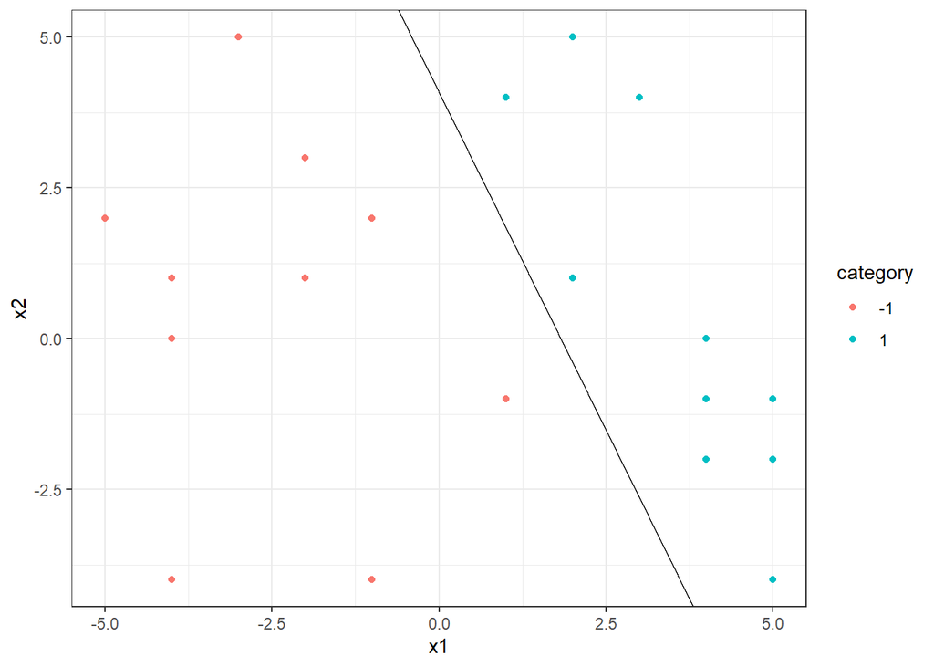

Generated Dataset

The figure above shows an generated dataset $D$ with $d = 2$ and $x_i^n \in R[-5, 5]$

```
## [1] "The perceptron learning algorithm took 6 updates to coverge, this occured in the 2th iteration"
```

The above output is the result of running a perceptron algorithm on the randomly generated dataset.

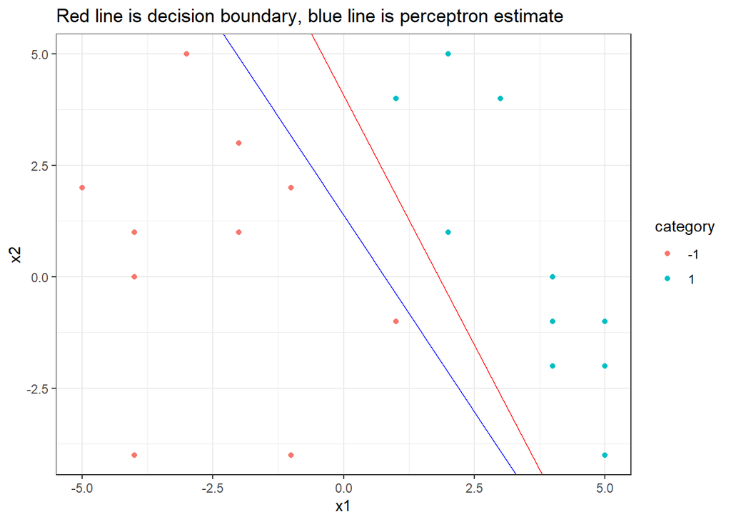

## Exercise 2

### 0.1.1 Question 2A

The $\mu$ of any given fair (simulated) coin, tossed 10 times will be 0.5.

### 0.1.2 Question 2B

See histogram below

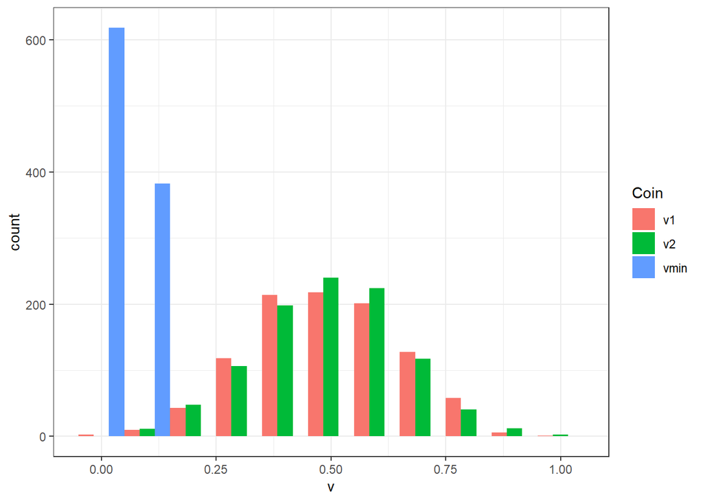

[output not shown]

### 0.1.3 Question 2C

See the Hoeffding bound and the estimates for $Pr[|v-\mu| >\epsilon]$ plotted below

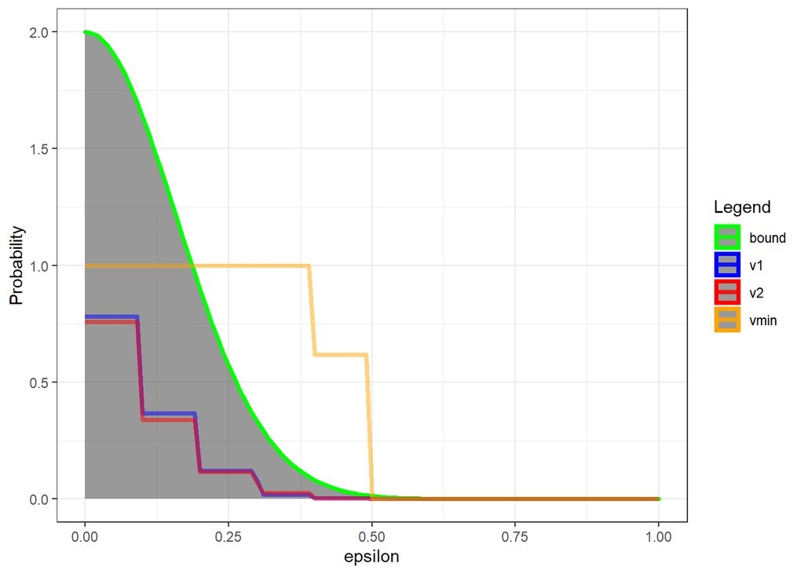

### Question 2D

It appears that $C_1$ and $C_2$ obey the Hoeffding inequality, while $C_min$ does not. This is because while the inequality applies to any individual bin before the sample data have been drawn, that is, we pick the random index of $C_2$ or say we will examine the first coin $C_1$ before drawing the samples. We can only examine $C_min$ after sampling the data, in effect, we are being picky about choosing a sample that best fits a certain hypothesis. If we were to test the hypothesis that $Pr[|v-\mu| >\epsilon]$ is small for all of 1000 coins, we must also modify the bound from $2e^{-2\epsilon^2N}$ to $2Me^{-2\epsilon^2N}$ where M is your number of hypotheses, in this case, 1000.

## 0.2 Exercise 3

Functions have been defined to generate the dataset for this exercise, to run the perceptron algorithm, as well as plot the results (code to animate the graphs have been commented out, but the animated .gif files are attached)

### 0.2.1 Question 3A

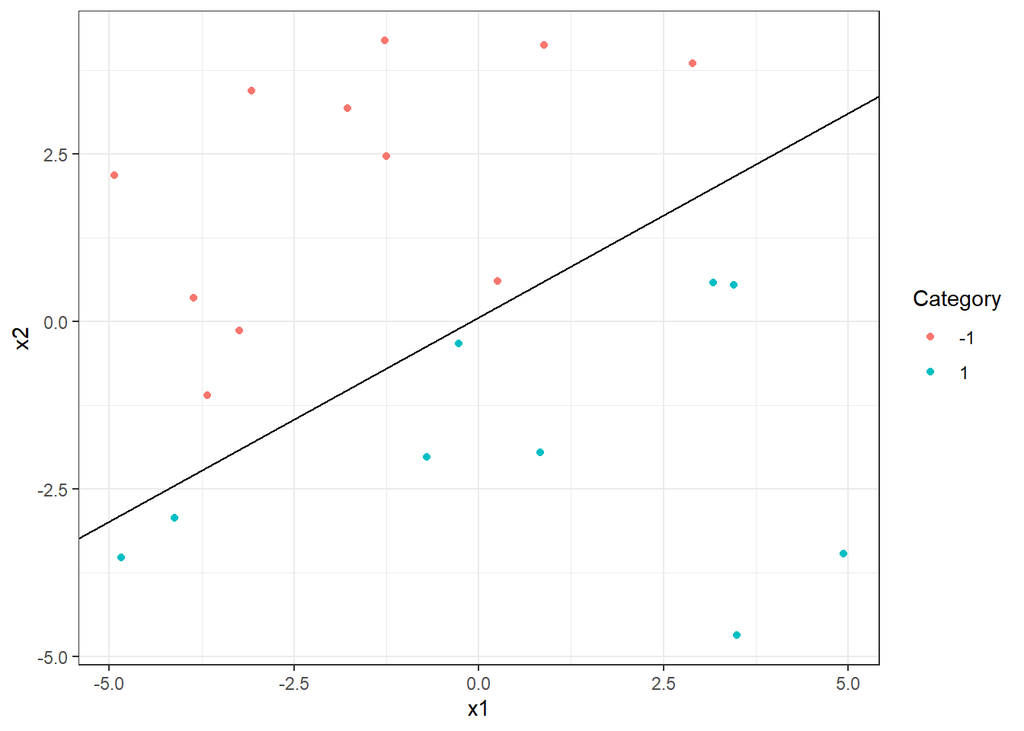

### Question 3B

[output not shown]

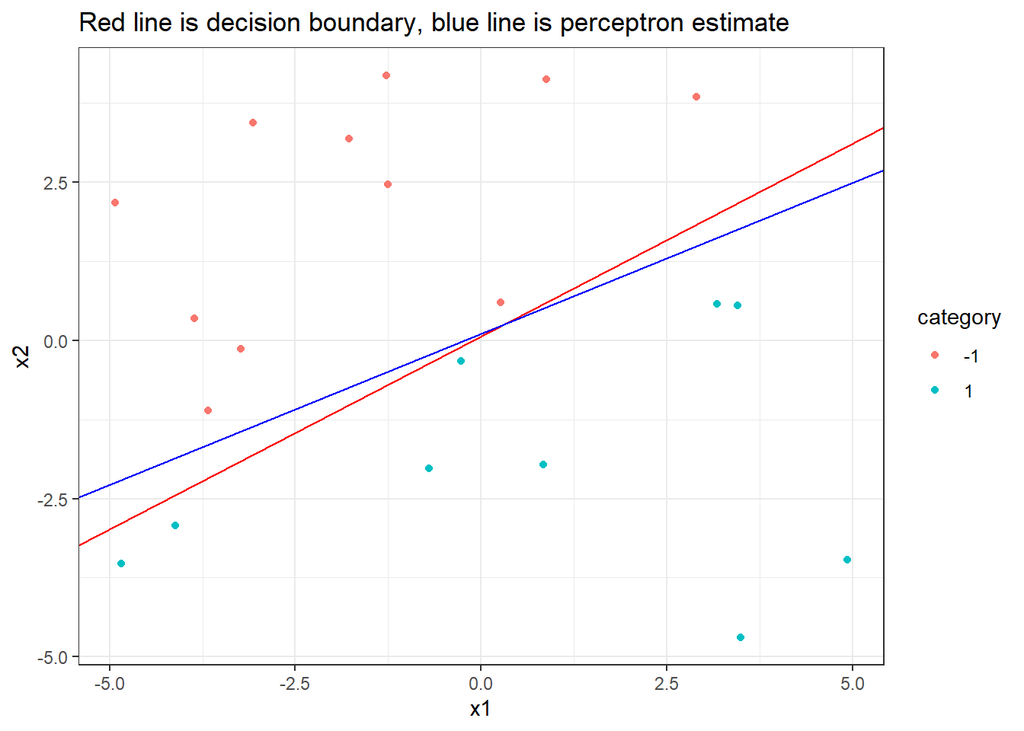

```
## [1] "The perceptron learning algorithm took 6 updates to converge, this occurred in the 2th iteration"
```

The estimated function $g$ is quite close to the target function $f$

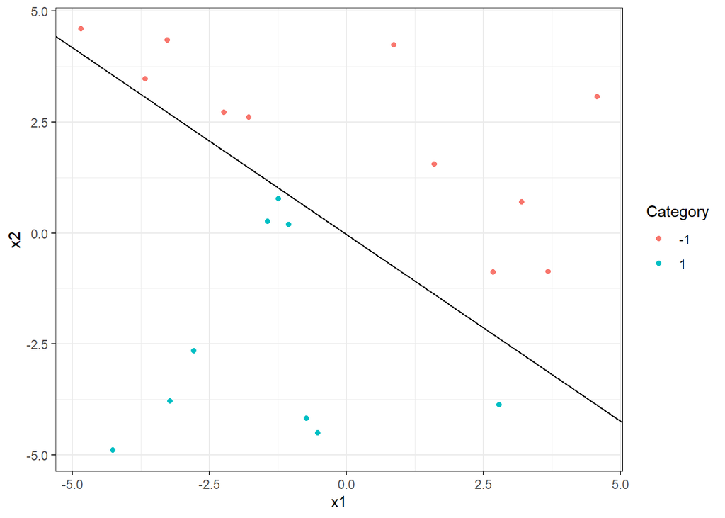

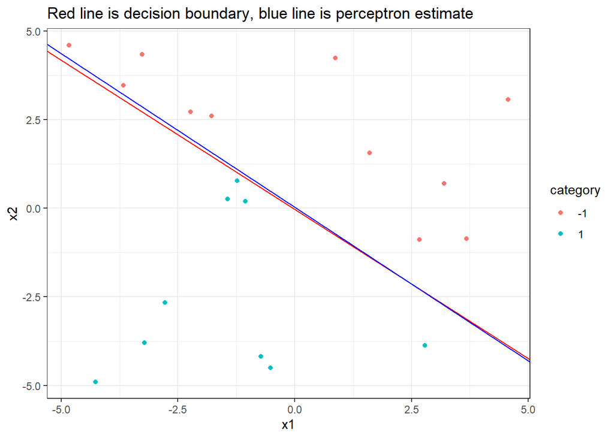

```
## [1] "The perceptron learning algorithm took 13 updates to converge, this occurred in the 3th iteration"
```

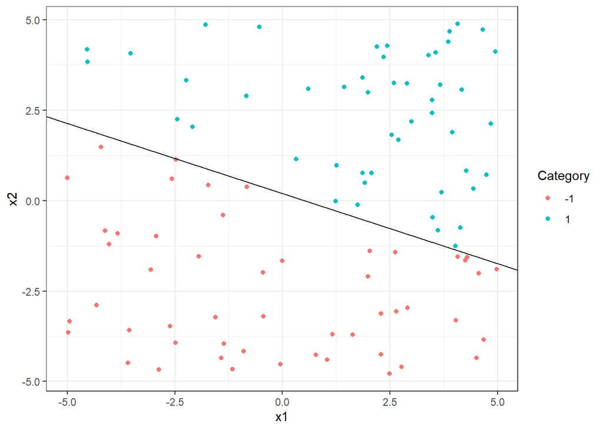

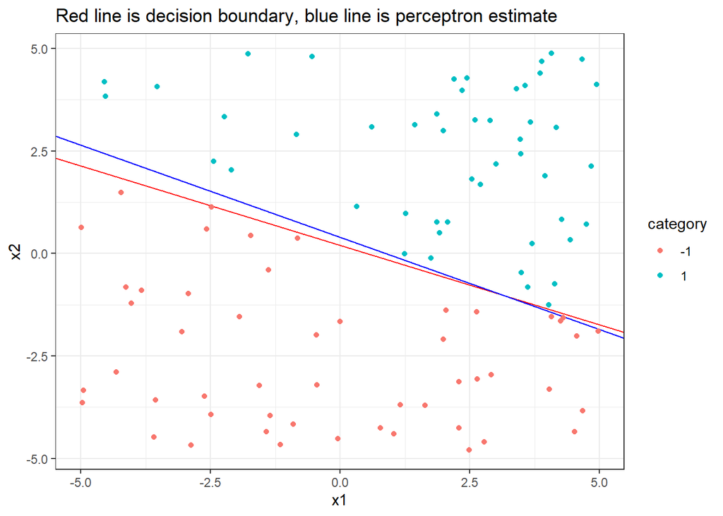

```
## [1] "The perceptron learning algorithm took 33 updates to converge, this occurred in the 4th iteration"
```

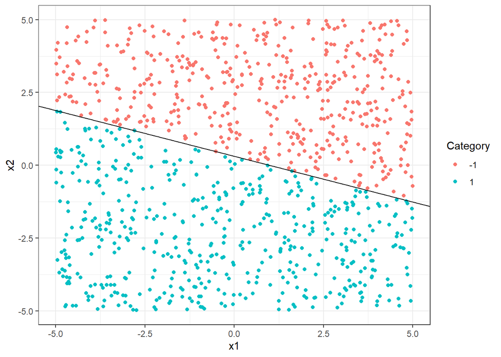

```
## [1] "The perceptron learning algorithm took 228 updates to converge, this occurred in the 21th iteration"
```

```
## [1] "The perceptron learning algorithm took 2267 updates to converge, this occurred in the 216th iteration"
```

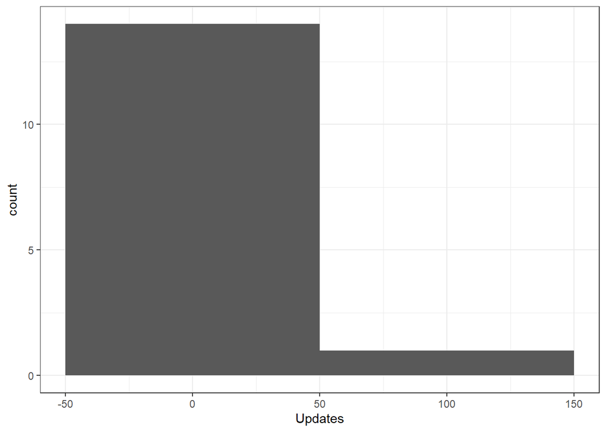